# Total Victims Analysis

Salma Emjaheed

12/06/2022

**Introduction:**

This data set came from Mother Jones researchers on four decades of mass shooting cases, from 1982 to 2022, including information on the attackers’ profiles, the types of weapons they used, and the number of victims they were injured and killed. Each row represents a mass shooting event. The values in the sources variable in the data link to websites that have news or more information about the mass shooting; this is how it was collected. For this data set, a mass shooting is defined as a shooting that occurred in a public place or a place filled with a crowd, such as private property where strangers (public crowd) were in it. Each case leading up to year 2012 was of a mass shooting where at least four people died. And the cases from the years 2013 to 2022 are of mass shootings where at least three people died to match the federal definition of what a mass shooting is. For each case, only one shooter was involved, except in two cases where two shooters were involved. There are some spree killings, as opposed to mass shootings, where the shootings happen in different locations but over a short period and by the same perpetrator. In many cases, the perpetrators were killed or wounded, either by themselves or someone else; in this data set, they are not counted under the variable total victims. The variables are case, location, date, summary, fatalities, injured, total victims, prior signs of mental health issues, mental health details, weapons obtained illegally, where the weapons were obtained, weapon type, weapon details, race, gender, latitude, longitude, type, and year. I want to take a look at how the demographics (age, race, and gender) of the perpetrators changed over the years, starting in 1982.

Research question: What factors can predict total victims in a mass shooting? I assumed that prior signs of mental health issues is a great predictor for total victims.

**Data Wrangling:**

First, I renamed location…8 and location…2 to location_type and location. This dataset had two columns named location, so r named them location …8 and location…2.

I added a new data set called regions and inner joined it with the mother Jones data set to use regions to predict total victims instead of states. The regions dataset had two unnecessary columns, which I removed with the select function.

I also separated the location column values, which had city and state separated by a comma. I used the separate() function, creating two columns: state and city. The gender column had five levels “F,” “M,” “Female,” “Male,” and “Female & Male.” I cleaned that up with mutate and case_when, creating only three levels.

The location type column had two “workplace” levels, one with an uppercase “W” and one with a lowercase “w.” Also, with the column race, the black and white categories had the same problem, and I fixed it the same way by case_when and made the level names start with the same letter case.

For the weapon’s legally obtained, I changed all the “yes” to “Yes.” I also changed ‘Yes (“some of the weapons were purchased legally and some of them may not have been”)’ to “Yes.” I chose yes instead of some. Because with some, it would create an extra level. I did not want to create an extra category because I wanted to use this variable to predict total victims later. “Yes” seemed the most logical because it had “Yes” before the parenthesis. I also mutated “Kelley passed federal criminal background checks; the US Air Force failed to provide information on his criminal history to the FBI” to NA. There were multiple new line characters within different levels, which I removed as well.

Also, for the race column, one value was “unclear,” so I grouped that with NA. Because if it is not clear, we do not know the race of the person, so it would not be available. I did the same with prior signs of mental health issues, where I put TBD, Unclear, and Unknown under NA to reduce the levels.

For the shooter age column, there were three NAs. I found their ages in the details columns, so I mutated them and changed those NA to the correct age of the shooter.

There were two rows where a female and a male were involved. I filled in one with “47 & 50”, which is information I took from the summary column. The other row, where two shooters were involved, however, is filled in with age 28. Does that mean both shooters were 28? Or is there a mistake?

For total victim variables and other variables necessary for this analysis, I made the ones I assumed to be numeric as numeric and not categorical.

I reduced the levels in multiple categorical variables. For example, some categories had NAs and Unknowns. I put these levels together as one level under NAs.

**EDA and Data Visualizations Explanations:**

This data set shows that only three female shooters were involved in mass shootings, and the rest were men. I tried to use it as a predictor, but the p-value was greater than .05. Most of them were men, which initially made me think it will not serve well as a predictor. I filtered out where it was both females and males involved in the same case because I felt that the absence of these columns will not change the results since I am filtering out an equal ratio of females and males. This also decreased the levels. But, it did not serve as a good predictor because the r-squared did not increase. Instead, it remained the same when I added it as the third predictor, along with the year and age of the shooter.

After removing the outliers and looking at the summary statistics of the total victims, the maximum number of total victims is 100. When I initially looked at the distribution of total victims, I saw that outlier and thought it was necessary to remove it because of how far it was from the maximum. The minimum is three, which looks accurate as this data set is not looking at shootings, where less than 3 died. The data is very rightly skewed, which is a good thing because it means that the number of total victims is usually on the lower side of the spectrum here in the U.S.

For the age of the shooter column, there are two columns where two shooters were involved in the mass shootings case. One of them has both shooter’s ages, noted as “47 & 50” because it has a “&” symbol where it turns all the values in the column into strings. Because I mutated that entire column to be in the numeric form before I moved on to Exploratory Data Analysis, any graph that I created excluded 47 & 50.

Finally, I wanted to show the progression of mass shooting cases throughout the years as the variable years served as a good predictor for total victims.

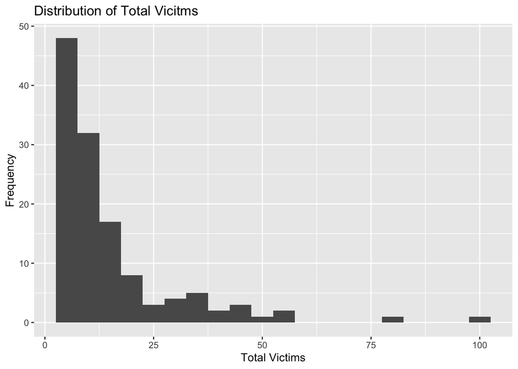

```
## # A tibble: 1 × 5
##    Mean Maximum Minimum Median    SD
##   <dbl>   <dbl>   <dbl>  <dbl> <dbl>
## 1  15.0     102       3     10  15.2
```

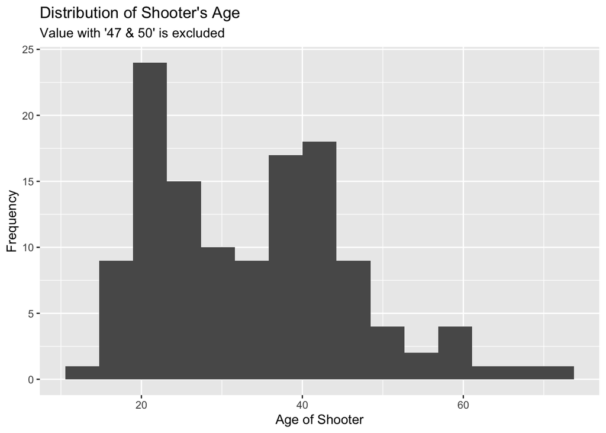

```
## # A tibble: 1 × 5
##    Mean Maximum Minimum Median    SD
##   <dbl>   <dbl>   <dbl>  <dbl> <dbl>
## 1  33.7      70      11     33  12.5
```

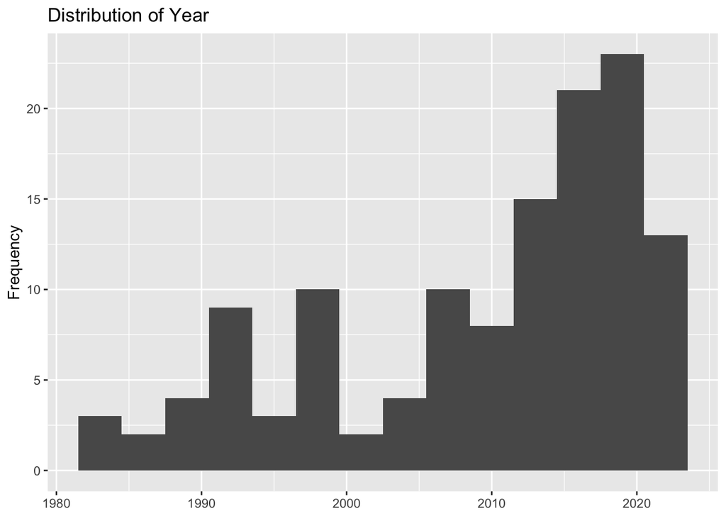

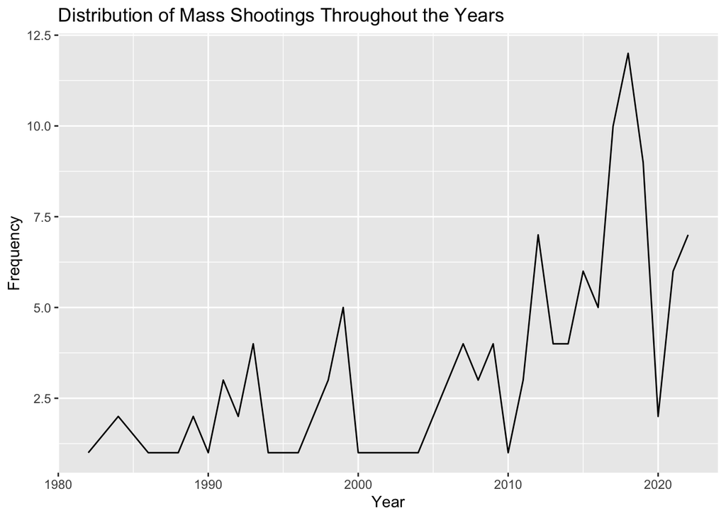

**Statistical Methods:**

I wanted to predict the total number of victims using the shooter”s age. The total victims’ column had an odd outlier, which was 600, while the number of total victims for the other cases was below 100. Looking at different websites, the numbers that about 58 died and more than 500 were hurt are accurate. I wanted to remove it anyway because it really skews the data, and removing it will not affect the results much because it is one number along with two other outliers, which were above 80.

There was also no correlation between region and total victims. All the p-values for each category were higher than .05, which accepts our null hypothesis. The 95% confidence interval for all categories include 0, confirming the null hypothesis. There was also no correlation between weapons obtained legally and total victims. The p-value for those who obtained their weapons legally was higher than .05, which accepts our null hypothesis. The 95% confidence interval between -0.347 and .408 includes 0, confirming the null hypothesis.

I did not look to see if fatalities or injuries can predict total victims because they both add up to total victims, so it would not make sense.

My last step was to combine the year and age of the shooter and used both as predictors of total victims. The p-values were less than .05. This model proved to be the better model because the adjusted r-square went up.

Overall, my technique was to manually forward selection, which I described above step by step.

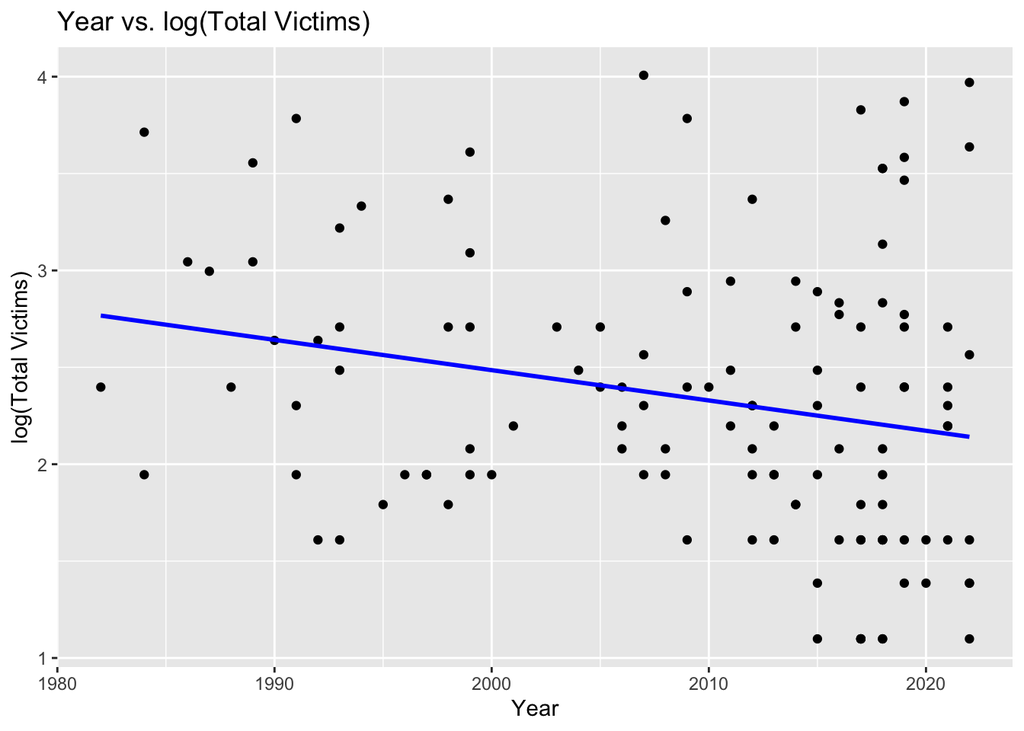

```
## # A tibble: 2 × 5
##   term        estimate std.error statistic p.value
##   <chr>          <dbl>     <dbl>     <dbl>   <dbl>
## 1 (Intercept)  33.8     11.9          2.83 0.00543
## 2 year         -0.0156   0.00594     -2.63 0.00951
```

```
##                   2.5 %       97.5 %
## (Intercept) 10.15337676 57.376730939
## year        -0.02739123 -0.003888385
```

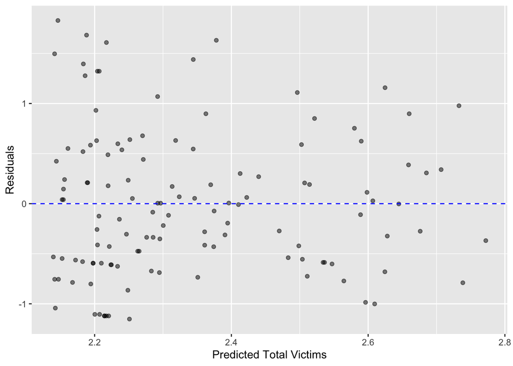

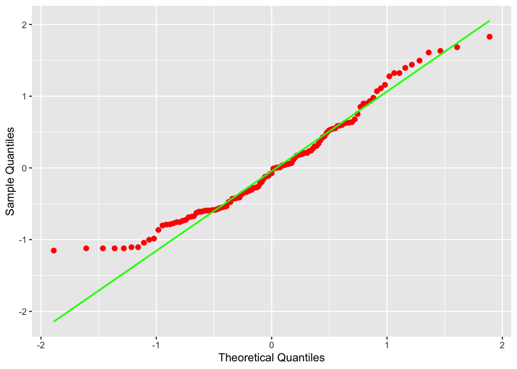

```
##
##  Shapiro-Wilk normality test
##
## data:  augment(m_total_victims_year)$.resid
## W = 0.96229, p-value = 0.001483
```

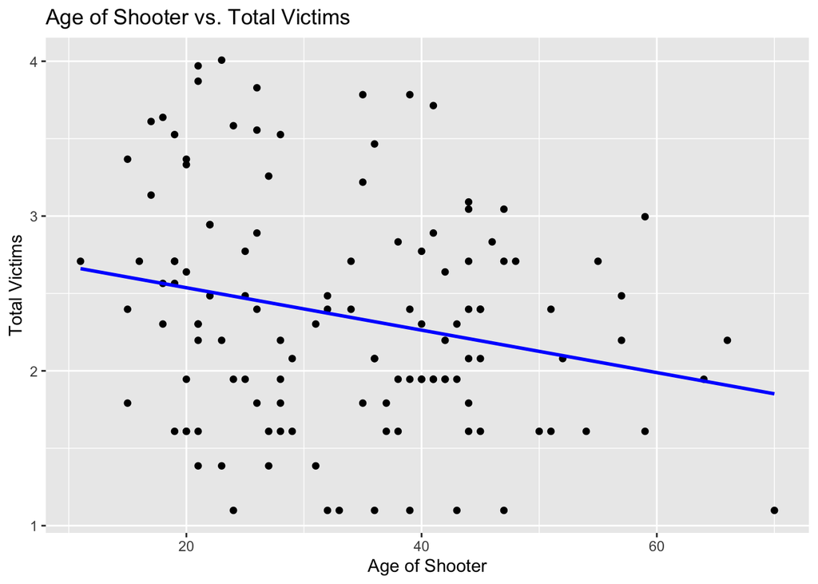

```
## # A tibble: 2 × 5
##   term           estimate std.error statistic  p.value
##   <chr>             <dbl>     <dbl>     <dbl>    <dbl>
## 1 (Intercept)      2.81     0.186       15.1  1.11e-29
## 2 age_of_shooter  -0.0137   0.00516     -2.66 8.91e- 3
```

```
##                      2.5 %       97.5 %
## (Intercept)     2.44344310  3.179100559
## age_of_shooter -0.02391528 -0.003498914
```

```
##
##  Shapiro-Wilk normality test
##
## data:  augment(m_total_victims_age)$.resid
## W = 0.97853, p-value = 0.04705
```

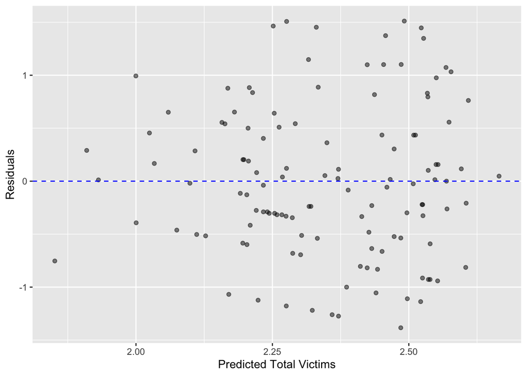

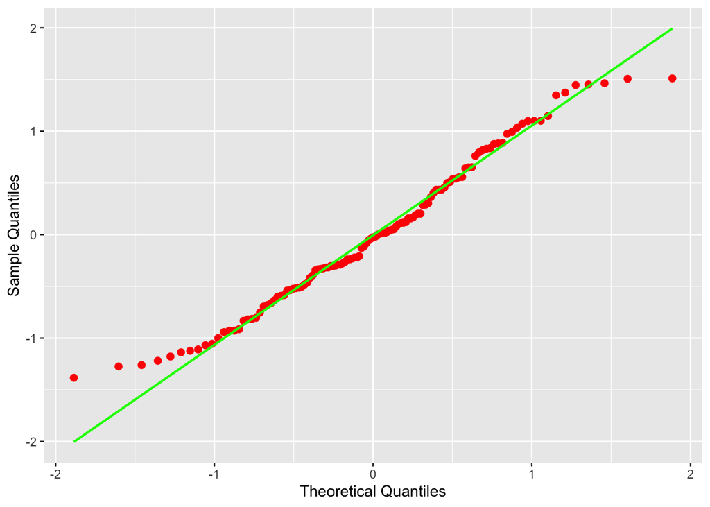

```
## # A tibble: 3 × 5
##   term           estimate std.error statistic p.value
##   <chr>             <dbl>     <dbl>     <dbl>   <dbl>
## 1 (Intercept)     39.5     11.8          3.34 0.00110
## 2 age_of_shooter  -0.0163   0.00505     -3.23 0.00161
## 3 year            -0.0182   0.00587     -3.11 0.00236
```

```
##                      2.5 %       97.5 %
## (Intercept)    16.13865839 62.957138879
## age_of_shooter -0.02630603 -0.006305313
## year           -0.02986463 -0.006619172
```

```
##
## Call:
## lm(formula = total_victims_log ~ age_of_shooter + year, data = mother_jones)
##
## Residuals:
##      Min       1Q   Median       3Q      Max
## -1.27255 -0.49429 -0.09858  0.48306  1.64993
##
## Coefficients:
##                 Estimate Std. Error t value Pr(>|t|)
## (Intercept)    39.547899  11.823264   3.345  0.00110 **
## age_of_shooter -0.016306   0.005051  -3.228  0.00161 **
## year           -0.018242   0.005870  -3.108  0.00236 **
## ---
## Signif. codes:  0 '***' 0.001 '**' 0.01 '*' 0.05 '.' 0.1 ' ' 1
##
## Residual standard error: 0.6939 on 120 degrees of freedom
##   (2 observations deleted due to missingness)
## Multiple R-squared:  0.1255, Adjusted R-squared:  0.111
## F-statistic: 8.614 on 2 and 120 DF,  p-value: 0.0003193
```

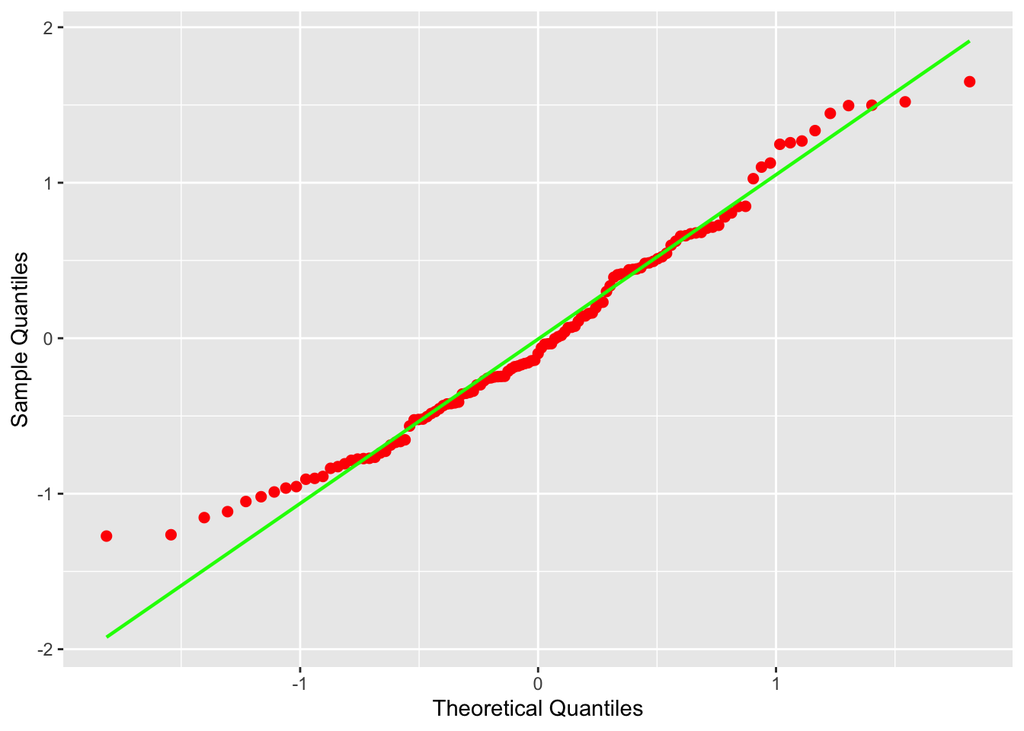

**Conclusion and Discussion:**

[output not shown]

In the model with year as the only predictor, the adjusted r-squared was 4.3%. In the model with the age of the shooter as the only predictor, the r-squared was 4.9%. In the model with both predictors, the r-squared was 11.1%. Adding an extra variable improved the model.

What I learned is that as the years progress, the total victim’s number decreases, which is good news. I also learned there aren’t many mass shootings in the US. Although interestingly, as the year’s increase, the number of cases also increases. This dataset spans from 1982 to 1922, and there are 133 cases, which is not as many as I thought it would be. It makes sense the number of victims decreases as the age of the shooter increases. The shooters are more likely to commit more damage when they are younger than older.

[output not shown]

[output not shown]